# Illuminating World Development

April 28, 2020

## Motivation

- How can we use big data to better understand developing countries?
- How to determine true economic data when official statistics are wrong or unavailable?
- Goal: Use satellites to track changes in light along with other traditional economic variables to predict GDP per capita
- Audience: international investors, international development NGOs

## Data Prep

- Yearly satellite data from NOAA 1993-2013, 30 GB
- Other economic data sourced from World Bank, IMF, OECD
- Used GeoPySpark to load and process the satellite data
- Polygonal mean of shapes for each country using pycountry

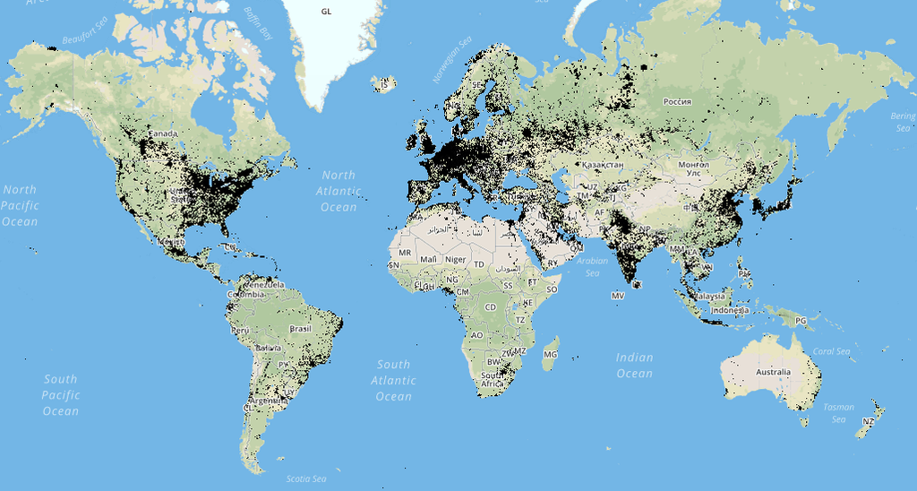

## EDA - light data processed

[interactive chart not shown]

## EDA - light data indexed to 1993

[interactive chart not shown]

## Preliminary Results

[interactive chart not shown]

- Linear regression (mean light only) RMSE = $17,312
- Linear regression RMSE = $13,691
- Random forest regression RMSE = $5,683

## Next Steps

- Try other model types, model parameters, and do more visualizations
- Try subsets of developing countries to see if explanatory power increases

## Summary

Challenges:

- JVM Heapspace errors when processing the data
- We found out how difficult mercader projections can be in spark
- Island nations had very high light values, using index helped

Takeaways:

- The wide variety of tools available to work with big data
- How to experiment with pyspark and parallel processing and get results
- How to optimize the core, heapspace, and memory parameters in Spark
- Prof. Vaisman should moonlight as a DJ